# Practical Machine Learning

Bernd Schnabl

Tuesday, October 22, 2014

## - Data import and cleasning

The training dataset contains many values that are not present, these are either blank “”, NA, or DIV/0. While importing the raw csv files, these values are replaced with NA and columns that contain at least one occurance of an NA values are removed in a second step.

A manual inspection of the data shows, that the first 7 columns contain data, which are not usable for predicting the outcome “classe”. These columns are: “X”, “user_name”, “raw_timestamp_part_1”, “raw_timestamp_part_2”, “cvtd_timestamp”, “new_window”, “num_window”.

```r
setwd("~/R/Coursera/DSSpec/assignments/C08-P01")

read.dataset <- function( fn ) {
  dsraw  <- read.csv(fn,header=T, strip.white=T, na.strings=c("NA","","DIV/0!"), sep=",")
  dsraw[,8:ncol(dsraw)] ## remove the first 7 columns
}

dsTestingFull <- read.dataset("pml-testing.csv")
dsTrainingFull <- read.dataset("pml-training.csv")

validColumnsTr <- ! apply( dsTrainingFull , 2 , function(x) any(is.na(x)) )
validColumnsTst <- ! apply( dsTestingFull , 2 , function(x) any(is.na(x)) )

dsTraining <- dsTrainingFull[ , names( validColumnsTr[validColumnsTr==TRUE])]
dsTesting  <- dsTestingFull[ , names( validColumnsTst[validColumnsTst==TRUE])]
dim(dsTraining)
```

```
## [1] 19622    53
```

The variable to predict is the classe variable. This variable has 5 levels, where A is the best and E ist the least perfect conducted training.

```r
unique(dsTrainingFull$classe)
```

```
## [1] A B C D E
## Levels: A B C D E
```

A correlation plot can be used to determine, if any features should be excluded, since they have a perfect negative or positive correlation.

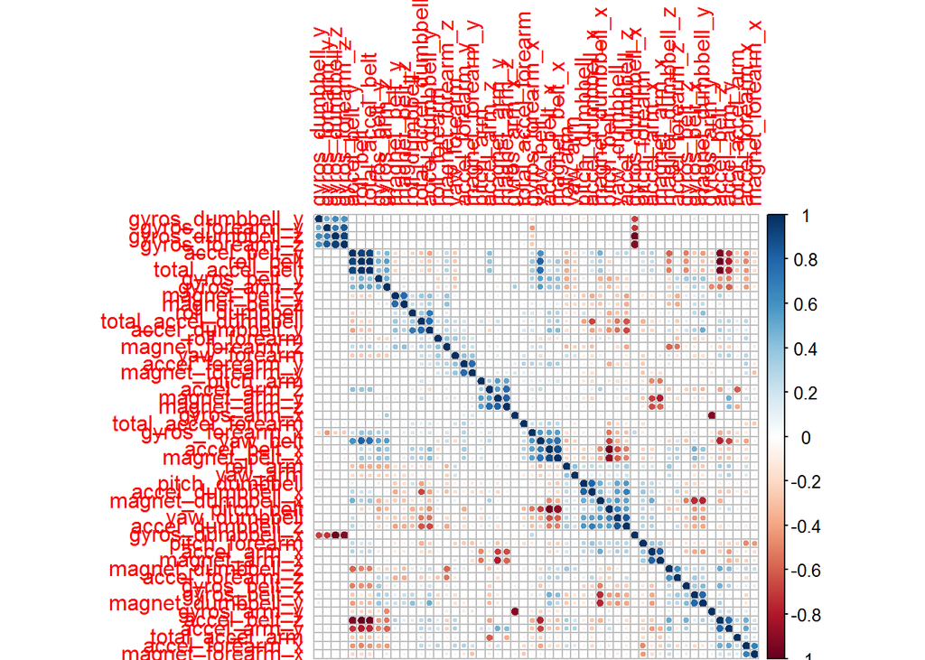

```r
library(corrplot)
M <- cor(subset(dsTraining, select=-c(classe)))
corrplot(M, order="hclust", sig.level = 0.0051)
```

## Random Forest Model

```r
library(caret)
library(randomForest)

inTrain <- createDataPartition(dsTraining$classe, p=0.7, list=F)
dsTraining_train <- dsTraining[inTrain,]
dsTraining_test <- dsTraining[-inTrain,]

TrainCtrlObj <- trainControl(
               method = "cv", # cross validation for out of sample error prediction
               number = 10, # 10 forld cross validation
               repeats =  1,
               p = 0.75,
               horizon = 1,
               returnData = TRUE,
               summaryFunction = defaultSummary,
               selectionFunction = "best",
               allowParallel = TRUE)

fit.rf <- train(
      classe ~ ., # predict classe wird all features
      data=dsTraining_train,
      method = "rf", # random forest
      preProcess = c("center", "scale", "knnImpute"), # principle component analysis "pca"
      #metric = ifelse(is.factor(y), "Accuracy", "RMSE"),
      #maximize = ifelse(metric == "RMSE", FALSE, TRUE),
      trControl = TrainCtrlObj) ## from TrainControl
```

## Print the importance of the variables

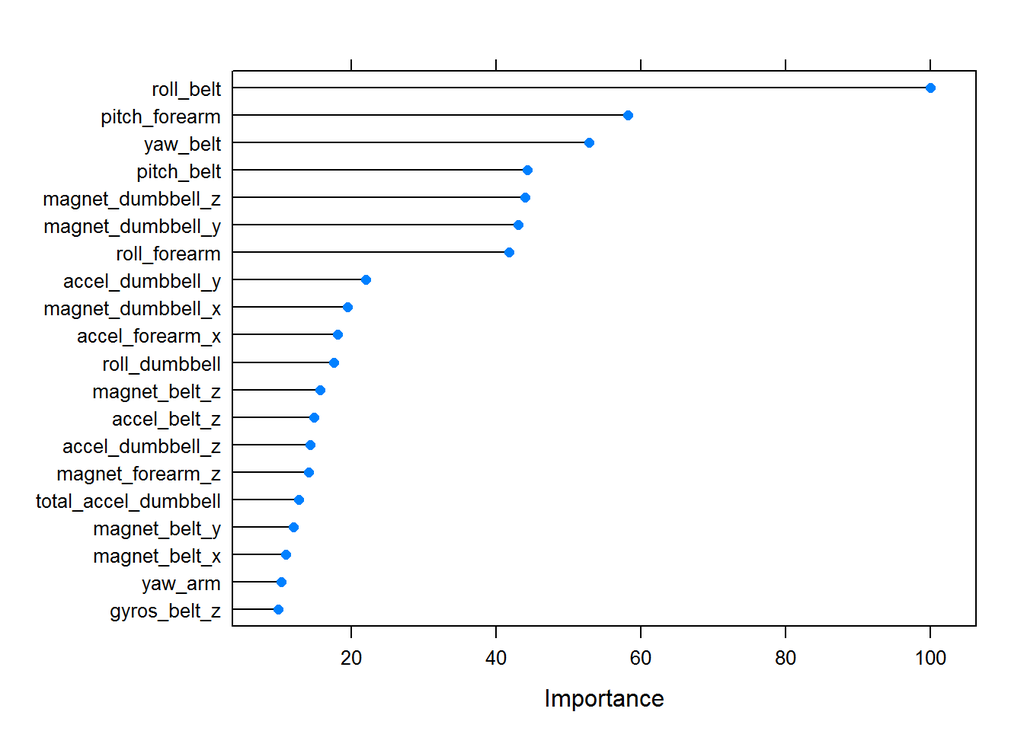

```r
plot(varImp(fit.rf, scale = T),top=20)
```

## Predicting out of sample errors

```r
fit.rf
```

```
## Random Forest
##
## 13737 samples
##    52 predictor
##     5 classes: 'A', 'B', 'C', 'D', 'E'
##
## Pre-processing: centered, scaled,  nearest neighbor imputation
## Resampling: Cross-Validated (10 fold)
##
## Summary of sample sizes: 12362, 12362, 12363, 12363, 12365, 12365, ...
##
## Resampling results across tuning parameters:
##
##   mtry  Accuracy  Kappa  Accuracy SD  Kappa SD
##    2    1         1      0.003        0.004
##   27    1         1      0.002        0.002
##   52    1         1      0.003        0.004
##
## Accuracy was used to select the optimal model using  the largest value.
## The final value used for the model was mtry = 27.
```

```r
predValues_test <- predict(fit.rf, newdata=dsTraining_test)
cm_test <- confusionMatrix(predValues_test, factor(dsTraining_test$classe))
cm_test
```

```
## Confusion Matrix and Statistics
##
##           Reference
## Prediction    A    B    C    D    E
##          A 1672   13    0    0    0
##          B    0 1123    7    0    0
##          C    1    3 1016    8    0
##          D    0    0    3  955    1
##          E    1    0    0    1 1081
##
## Overall Statistics
##
##                Accuracy : 0.994
##                  95% CI : (0.991, 0.995)
##     No Information Rate : 0.284
##     P-Value [Acc > NIR] : <2e-16
##
##                   Kappa : 0.992
##  Mcnemar's Test P-Value : NA
##
## Statistics by Class:
##
##                      Class: A Class: B Class: C Class: D Class: E
## Sensitivity             0.999    0.986    0.990    0.991    0.999
## Specificity             0.997    0.999    0.998    0.999    1.000
## Pos Pred Value          0.992    0.994    0.988    0.996    0.998
## Neg Pred Value          1.000    0.997    0.998    0.998    1.000
## Prevalence              0.284    0.194    0.174    0.164    0.184
## Detection Rate          0.284    0.191    0.173    0.162    0.184
## Detection Prevalence    0.286    0.192    0.175    0.163    0.184
## Balanced Accuracy       0.998    0.992    0.994    0.995    0.999
```

## Predicting the Results

The predictions on the testing dataset with the 20 samples based on the random forest model delivers these results

```r
res <- predict(fit.rf, dsTesting)
res
```

```
##  [1] B A B A A E D B A A B C B A E E A B B B
## Levels: A B C D E
```